# Основы работы в R Markdown

Зарманбетов Ахмед

### R Markdown

R Markdown – это язык разметки, который позволяет объединять код, его результаты, текст, графики и картинки. Он очень удобен для составления различных отчетов.

Давайте попробуем создать наш первый R Markdown(.Rmd) файл. Там, где мы создаем скрипт нужно выбрать R Markdown.

[figure not shown]

Далее выйдет окно, в котором нужно дать название отчета, имя автора, а также тип выходного файла. Используйте html, можно также пользоваться pdf, но для этого нужен установленный LaTeX.

[figure not shown]

После этого у вас откроется Rmd файл.

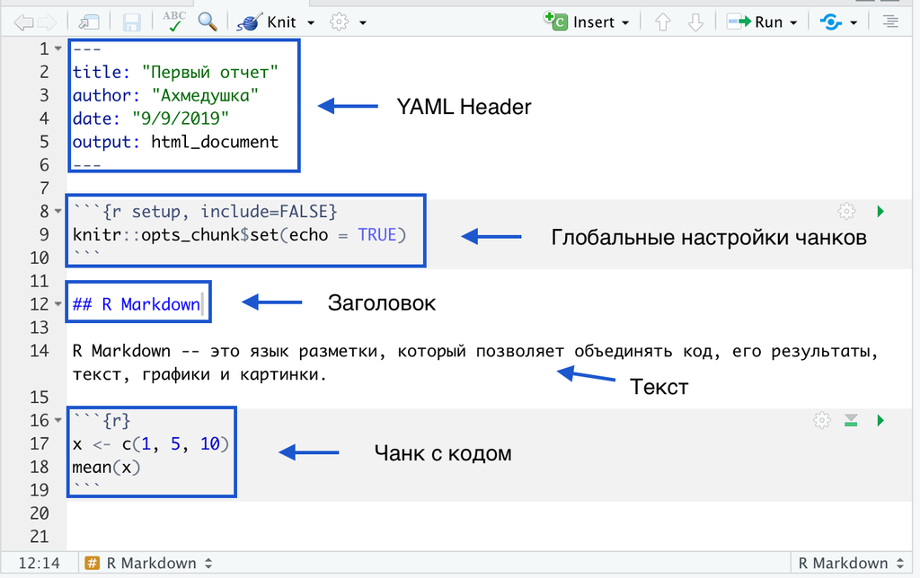

Любой Rmd файл состоит из следующих частей:

- YAML Header – шапка документа, в которой указываются различные настройки того как должен выглядеть итоговый файл.
- Глобальные настройки чанков – настройки, которые идут по умолчанию для всех чанков. Позже еще вернемся к этому более подробно.
- Заголовок – имеется 6 уровней заголовков, количество решеток показывает уровень заголовка.
- Текст – можно писать любой текст, который вы хотите.
- Чанк – создается для того, чтобы отделить код от текста. Внутри чанка пишется код.

Давайте попробуем собрать этот файлик. Чтобы это сделать, нужно нажать на кнопку **Knit**, которая находится на панели для файла. После нажатия у вас появится html файлик.

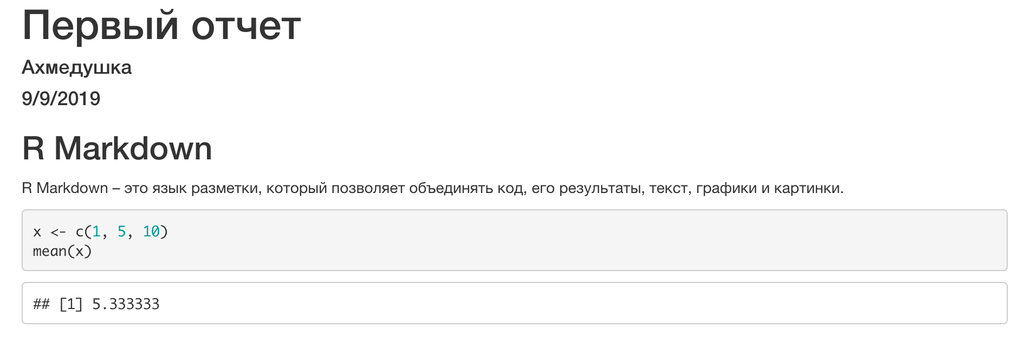

Видим, что код находится в отдельном окошке. А также его результат выносится в отдельное окошко.

### Основные элементы R Markdown

#### Жирный шрифт

Для выделения текста жирным можно использовать конструкцию **текст** или __текст__. Давайте попробуем! **Сегодня** мы изучаем R Markdown.

#### Курсивный шрифт

Чтобы сделать текст курсивным можно использовать конструкцию *текст* или _текст_. Пробуем! Для формирования отчетов удобно пользоваться *R Markdown*.

#### Моноширинный шрифт

Этот шрифт нужен для того, чтобы выделять куски кода прямо в тексте. Чтобы применить шрифт используем следующую конструкцию `текст`. Например, sum(x) не так заметен, как `sum(x)`.

#### Верхние и нижние индексы

Можно поставить верхний и нижний индексы. Сначала пишем выражение, которое будет иметь эти индексы. Далее для верхнего индекса ставим ^^ и между ними пишем, что будет содержаться в верхнем индексе, для нижнего аналогично, но пишем между ~~. Например: R<sup>2</sup><sub>i</sub> можно написать с помощью конструкции R^2^~i~.

#### Зачеркнутый текст

Чтобы зачеркнуть текст используйте конструкцию ~~текст~~. Например, я являюсь студентом преподавателем ВШЭ.

#### Экранирование служебных символов

Обратный слэш(\), звёздочка(*), знак доллара($) и нижнее подчеркивание(_) являются служебными командами. Но если вы хотите их напечать, то используйте перед этими знаками обратный слэш. \, $, _, * .

#### Тире и длинное тире

Чтобы использовать тире нужно поставить два знака минуса (--). Например, Среднее – это сумма всех значений деленное на их количество. Если же вы хотите использовать длинное тире, то нужно поставить три знака минуса (---). Пробуем! Дисперсия случайно величины — мера разброса значений случайной величины относительно её математического ожидания.

#### Гиперссылки

Чтобы выделить гиперссылку, нужно использовать конструкцию <ссылка>. Например, главная страница яндекса находится по адрессу https://yandex.ru . Иногда гиперссылка выглядит очень некрасиво и её можно спрятать. Для этого используем конструкцию [текст] (ссылка), без пробела между скобками. Сделаем наше последнее предложение более красивым. [Главная страница](https://yandex.ru) яндекса.

### Чанк

Чанк создается, для того, чтобы R Markdown понимал где находится код, который нужно запустить.

Чанк можно создать с помощью кнопки **Insert**.

Выглядит он следующим образом.

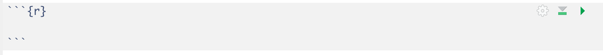

Внутри этого блока и нужно писать код. Буква r в фигурных скобках означает, что в чанке будет код на языке R. Дело в том, что можно использовать несколько языков программирования сразу.

### Опции чанка

У чанков могут быть разные опции. Опции перечисляются через запятую внутри первых фигурных скобок.

#### echo

Данная опция может принимать логическое значение: `TRUE` или `FALSE`(default:`TRUE`). Она отвечает за вывод кода, находящийся в чанке. То есть код не будет отображен, но будет запущен и будет дан результат. Давайте попробуем на примере.

Просто выведем “Hello world!” и выставим `TRUE` в опции echo.

```r
print('Hello world!')
```

```
## [1] "Hello world!"
```

А теперь попробуем выставить `FALSE.` Посмотрим, что поменяется.

```
## [1] "Hello world!"
```

Как видно, теперь код не высвечивается, но результат мы видим.

#### eval

Данная опция может принимать логическое значение: `TRUE` или `FALSE`(default:`TRUE`). Отвечает за исполнение кода в чанке. То есть, код не будет запущен, следовательно не будет и резульата. Это удобно, когда вы хотите показать только код.

```r
print('Hello world')
```

```
## [1] "Hello world"
```

А теперь попробуем выставить `FALSE`. Посмотрим, что поменяется.

```r
print('Hello world')
```

#### include

Данная опция может принимать логическое значение: `TRUE` или `FALSE`(default:`TRUE`). Отвечает за отображение кода и результата исполнения чанка. Удобно, если вы хотите сделать какие-то простые операции, но не хотите показывать ни код, ни результат.

```r
m <- 10
m
```

```
## [1] 10
```

Если выставить `FALSE`, то код запустится, но мы не увидим ничего в документе.

#### message и warning

Даннык опции могут принимать логические значение: `TRUE` или `FALSE`(default:`FALSE`). Предотвращает появление сообщений или предупреждений в конечном файле.

#### error

Данная опция может принимать логическое значение: `TRUE` или `FALSE`(default:`FALSE`). Если у вас имеется ошибка в чанке, то файлик не соберется. Если вы все таки хотите увидеть файлик и заняться ошибкой позде, то можно поставить этот параметр равный `TRUE`.

```r
'name' + 5
```

```
## Error in "name" + 5: нечисловой аргумент для бинарного оператора
```

#### comment

Данная опция может принимать строковое значение(default:‘##’). Отвечает за префикс перед каждой строкой вывода результата.

```r
print('Hello world')
```

```
## [1] "Hello world"
```

А теперь поменяем префикс.

```r
print('Hello world')
```

```
-> [1] "Hello world"
```

#### highlight

Данная опция может принимать логическое значение: `TRUE` или `FALSE`(default:`TRUE`). Отвечает за подсвечивание синтаксиса кода.

#### collapse

Данная опция может принимать логическое значение: `TRUE` или `FALSE`(default:`FALSE`). Можно объединить вывод кода в один блок или несколько.

```r
print(2 + 2)
## [1] 4
print('Hello world!')
## [1] "Hello world!"
```

А теперь с `FALSE`.

```r
print(2 + 2)
```

```
## [1] 4
```

```r
print('Hello world!')
```

```
## [1] "Hello world!"
```

Остальные опции чанков можно найти по этой [cсылке](https://yihui.name/knitr/options/).

### Дефолтные значения чанков

Например, вы хотите показывать в файле только код. Для этого в каждом чанке нужно написать `eval=FALSE`. Чтобы этого не делать, в самом начале файла после YAML Header идет чанк, в котором можно установить дефолтные значения опций чанков.

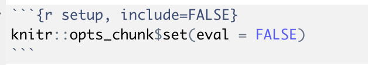

### Inline code

В R Markdown можно вставлять значение какой-то переменной прямо в текст. Давайте попробуем. Создадим матрицу.

```r
m <- matrix(1:12, nrow = 3, ncol = 4)
```

В матрице `m` имеется 4 столбцов и 3 строчек.

### LaTeX в R Markdown

Есть такой язык верстки как LaTeX! С его помощью можно делать крутые формулы.

Формулы можно записывать между двумя долларами: $тут формула$.

Первый замечательный предел: $\lim_{x \to 0}\frac{\sin(x)}{x} = 1$ .

Выглядит не очень. Формулу лучше выносить на отдельную строчку. Чтобы это сделать используем двойные знаки доллара.

Второй замечательный предел:)
$$\lim_{n \to \infty} \left(1+\frac{1}{n}\right)^n = e$$

### Списки

#### Нумерованный список

Чтобы сделать нумерованный список можно просто ставить цифру с точкой и сделав отступ.

1. Рассказать про некоторые фишки в R.
2. Разобрать R Markdown.
3. Дать домашку.

#### Маркированный список

- R
- RStudio
- R Markdown

#### Двойной список

1. Python
   - PyCharm
   - IPython
   - Jupyter notebook
2. R
   - RStudio
   - Jupyter notebook

### Блоки

A friend once said:

> It’s always better to give than to receive.

```
Тут должна быть цитата)
```

### Картинки

[figure not shown]

Картинка в студию

### Таблички

Таблички делаются следующим образом.

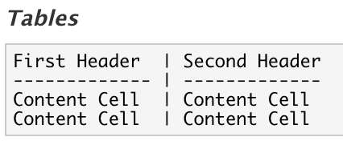

| First Header | Second Header |
| --- | --- |
| Content Cell | Content Cell |
| Content Cell | Content Cell |

### Горизонтальная линия

Можно сделать горизонтальную линию, которая горизонтально поделит файл. Сделать можно с помощью 3 или более тире подряд.

### HTML

Обычно инструментов R Markdown хватает, чтобы делать отчеты. Но так как на выходе вы получаете HTML страничку, вы можете пользоваться и инструментами HTML.

Например, создавать таблички удобным способом на [сайте](https://daruse.ru/html-table-generator). А потом просто вставлять код, который получили.

Или менять цвет текста.

| Код | Текст |
| --- | --- |
| <font color=“red”>This is some text!</font> | This is some text! |
| <font color=“green”>This is some text!</font> | This is some text! |
| <font color=“blue”>This is some text!</font> | This is some text! |

### YAML Header

В YAML Header можно добавлять очень много классных штук. Например, если вы знаете CSS, то можете добавить какую-то стилистику вашему файлу. Также можно задать удобную навигацию с помощью параметров `toc` и `toc_float`. Есть очень много параметров, которые можно прочитать в документации.

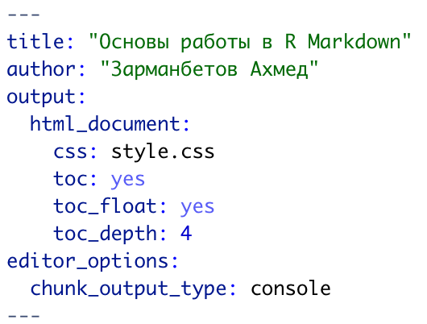

### Примечания

Материалы по $\LaTeX$ можно найти на репозитории моего друга.[^1]

Также можно посмотреть курс от ВШЭ на Coursera[^2]

[^1]: [Страничка Филиппа на GitHub](https://fulyankin.github.io/LaTeX/)
[^2]: [Курс по $\LaTeX$](https://www.coursera.org/learn/latex)